# Partial Least Squares Discriminant Analysis (PLS-DA)

Sonia Tarazona & Maider Aguerralde

2026-05-25

```r
library(knitr)
knitr::opts_chunk$set(echo = TRUE)
library(caret)
# install.packages("devtools")
# pak::pak("BiostatOmics/PLSandO")
library(PLSandO)
library(gridExtra)
```

# 1 PLS-DA 2 Classes Example

## 1.1 Data Loading and Preparation

In this section we will use the breast tumour dataset, which contains information extracted from medical images and the classification of each tumour as benign or malignant (response variable).

```r
load("BreastCancer.RData")
```

## 1.2 PLS-DA Model Estimation and Number of Components

In this case, we will scale the **X** matrix within the *pls* function itself and apply repeated k-fold cross-validation to estimate the number of components. We will split the data into training (80%) and test (20%) sets.

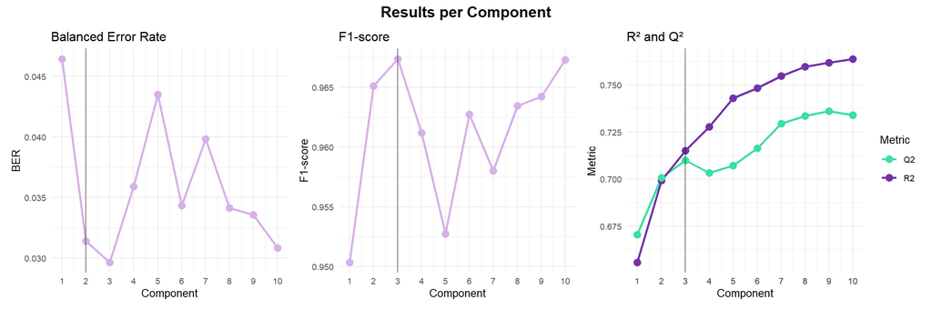

```r
set.seed(100)
myplsda = PLSandO::plsda(x = X, y = y, ncomp = NULL, cvFolds = 10, rep = 3,
                         perm = 20, scaling = "standard", train = 0.8)
plsdaPlot(myplsda, type = 'ncomp')
```

The model estimates 2 as the optimal number of components, applying in the case of PLS-DA the search for the first elbow in the *Balanced Error Rate* (BER) metric. However, the F1-score and the criterion used in PLS (the $R^2$ and $Q^2$ rule) suggest 3 components. Since the response variable in PLS-DA is categorical, the latter criterion is usually less appropriate. It may be advisable to plot score graphs for all 3 components and ensure that with only two we can perfectly separate benign and malignant tumours.

The following table shows the error metrics displayed in the plots and some additional ones, both for the training data and the test data. All metrics show fairly good values.

```r
resumen = myplsda$summary
resumen[,-1] = round(resumen[,-1], 4)
kable(t(resumen))
```

| comp | 1 | 2 |
| --- | --- | --- |
| R2X | 0.4499 | 0.1607 |
| cumR2X | 0.4499 | 0.6105 |
| R2Y | 0.6557 | 0.0436 |
| cumR2Y | 0.6557 | 0.6993 |
| R2Xtest | 0.4198 | 0.1726 |
| cumR2Xtest | 0.4198 | 0.5924 |
| R2Ytest | 0.6543 | 0.0272 |
| cumR2Ytest | 0.6543 | 0.6816 |
| Q2 | 0.6704 | 0.0302 |
| cumQ2 | 0.6704 | 0.7006 |
| RMSE | 0.2776 | 0.2646 |
| F1score | 0.9322 | 0.9559 |
| F1scoretest | 0.9077 | 0.9442 |
| MCC | 0.8646 | 0.9126 |
| MCCtest | 0.8209 | 0.8910 |
| Etot | 0.0636 | 0.0417 |
| Etottest | 0.0885 | 0.0531 |
| BER | 0.0662 | 0.0392 |
| BERtest | 0.0801 | 0.0471 |

## 1.3 Validation of the PLS-DA Model

We can use the same strategies and functions shown in the previous examples to validate our model.

## 1.4 Interpretation of the PLS-DA Model

Although, as shown earlier, more plots can be obtained, we will focus on the *scores* and *weights* plots to interpret this model. Since the number of predictor variables is very large, we only show the most relevant 30%.

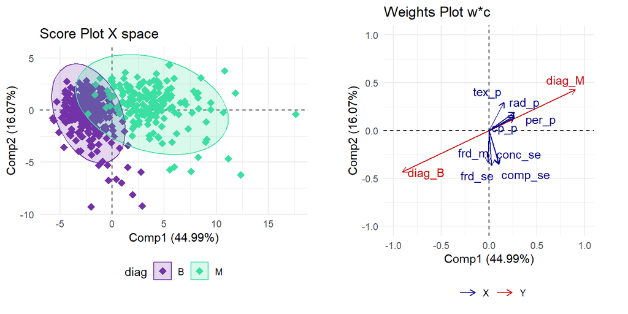

```r
p1 = plsdaPlot(myplsda, type = 'scoresX', comp = 1:2)
p2 = plsdaPlot(myplsda, type = 'weights', comp = 1:2,
               selVars = 0.3, col = c("red3", "blue4"))
grid.arrange(p1, p2, nrow = 1)
```

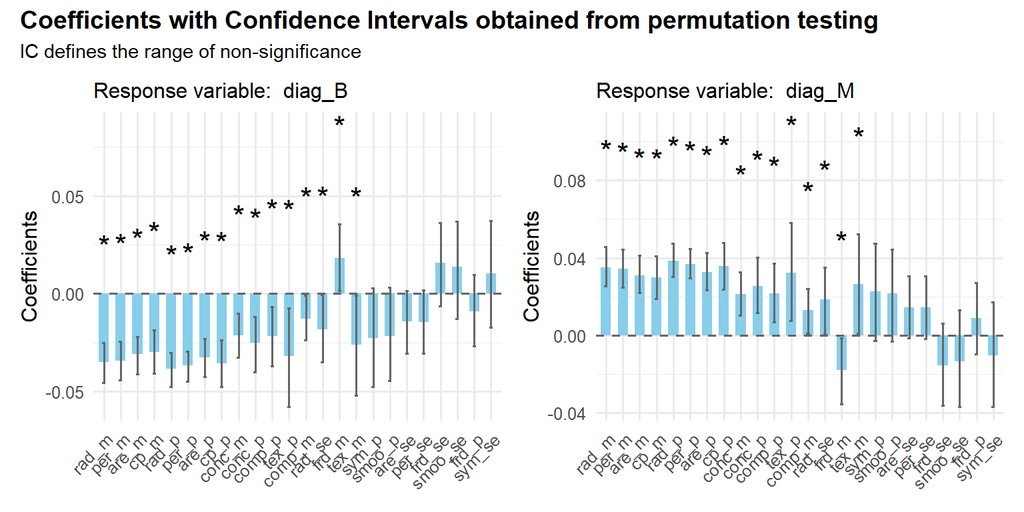

```
## $diag_B
##        pValPerm
## rad_m     0.000
## per_m     0.000
## are_m     0.000
## cp_m      0.000
## rad_p     0.000
## per_p     0.000
## are_p     0.000
## cp_p      0.000
## conc_m    0.002
## conc_p    0.003
## comp_p    0.009
## tex_p     0.013
## comp_m    0.031
## rad_se    0.040
## frd_m     0.043
## tex_m     0.045
##
## $diag_M
##        pValPerm
## rad_m     0.000
## per_m     0.000
## are_m     0.000
## cp_m      0.000
## rad_p     0.000
## per_p     0.000
## are_p     0.000
## cp_p      0.000
## conc_m    0.002
## conc_p    0.003
## comp_p    0.009
## tex_p     0.013
## comp_m    0.031
## rad_se    0.040
## frd_m     0.043
## tex_m     0.045
```

```r
plsVarSel(myplsda, type = "Perm", rep = 1000, selVars = 0.8)
```

Based on the variables selected using the permutation technique, we could fit a new PLS-DA model and evaluate its error metrics, as we will do in the next section for the full model (with all variables).

## 1.5 Error Metrics in PLS-DA

In this case, we can calculate the error metrics both for the training data and for the test data.

For the training data:

```r
mypred = predict(myplsda, plot = FALSE)
mypred = factor(mypred$Class$diag)
myobs = myplsda$input$Y$diag
caret::confusionMatrix(mypred, myobs, positive = "M")
```

```
## Confusion Matrix and Statistics
##
##           Reference
## Prediction   B   M
##          B 286  20
##          M   0 150
##
##                Accuracy : 0.9561
##                  95% CI : (0.9331, 0.973)
##     No Information Rate : 0.6272
##     P-Value [Acc > NIR] : < 2.2e-16
##
##                   Kappa : 0.9039
##
##  Mcnemar's Test P-Value : 2.152e-05
##
##             Sensitivity : 0.8824
##             Specificity : 1.0000
##          Pos Pred Value : 1.0000
##          Neg Pred Value : 0.9346
##              Prevalence : 0.3728
##          Detection Rate : 0.3289
##    Detection Prevalence : 0.3289
##       Balanced Accuracy : 0.9412
##
##        'Positive' Class : M
##
```

For the test data (or for future new observations), we can also obtain predictions from the fitted PLS-DA model. In this case, it is important to verify that the new observations belong to the same population as the training data. If this is not the case, making predictions on them would not be meaningful. To assess this, the plot generated by the **predict()** function projects the new observations onto the latent space of the fitted model.

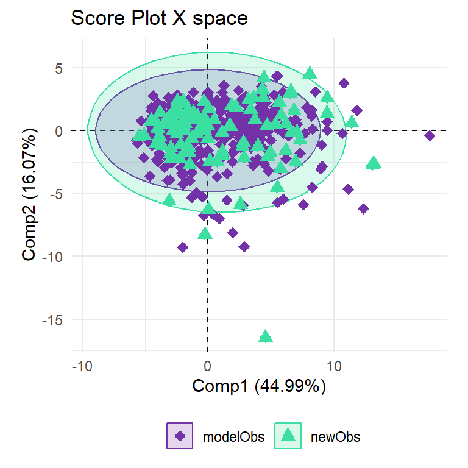

```r
mypred = predict(myplsda, new = myplsda$test$input$xTest, plot = TRUE)
```

We can observe in the plot that all test data observations, except one in the lower right that deviates along the second component (which is less relevant), are projected onto the space occupied by the training data, so it makes sense to apply the fitted model to them for prediction.

Therefore, let us look at the error metrics for the test data. The object obtained via the **predict()** function contains the following elements: yPred, yProb, Class, corresponding to the numerical predictions for each class, the probabilities of belonging to each class (estimated using the *softmax* procedure), and the class predicted by the model.

```r
mypred = factor(mypred$Class$diag)
myobs = factor(myplsda$test$input$yTest$diag)
caret::confusionMatrix(mypred, myobs, positive = "M")
```

```
## Confusion Matrix and Statistics
##
##           Reference
## Prediction  B  M
##          B 71  4
##          M  0 38
##
##                Accuracy : 0.9646
##                  95% CI : (0.9118, 0.9903)
##     No Information Rate : 0.6283
##     P-Value [Acc > NIR] : <2e-16
##
##                   Kappa : 0.9227
##
##  Mcnemar's Test P-Value : 0.1336
##
##             Sensitivity : 0.9048
##             Specificity : 1.0000
##          Pos Pred Value : 1.0000
##          Neg Pred Value : 0.9467
##              Prevalence : 0.3717
##          Detection Rate : 0.3363
##    Detection Prevalence : 0.3363
##       Balanced Accuracy : 0.9524
##
##        'Positive' Class : M
##
```

# 2 PLS-DA 3 Classes Example

We return to the olive oil example data already used at the beginning of this tutorial. Our response variable will be the origin of the oil (*proced*) and we will use both matrices **X** and **Y** as predictor variables.

```r
load("OliveOils.RData")
Xda = cbind(X, Y)
y = data.frame("proced" = proced)
```

## 2.1 PLS-DA Model Estimation

Since we have few observations, as in the PLS2 model, we will not split the data into training and test sets, and we will use LOO cross-validation to estimate the optimal number of components.

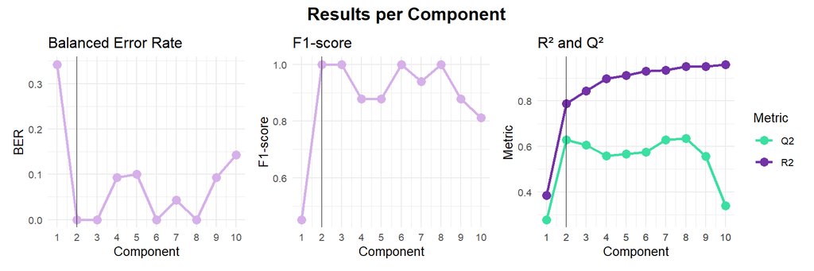

```r
myplsda = plsda(x = Xda, y = y, ncomp = NULL, cvFolds = nrow(Xda), rep = 1,
                perm = 40, algo = "nipals", train = 1, alpha = 0.05,
                scaling = "standard", parallel = FALSE)
plsdaPlot(myplsda, type = 'ncomp')
```

Based on these results, all metrics agree that 2 components is a reasonable choice for clearly separating the oil origins.

## 2.2 Model Validation

### 2.2.1 Detection of Outliers

In the following plots we represent the Residual Sum of Squares and Hotelling’s $T^2$ with their respective confidence limits (99%).

```r
anomalos = plsOutliers(myplsda, conf = 0.99)
```

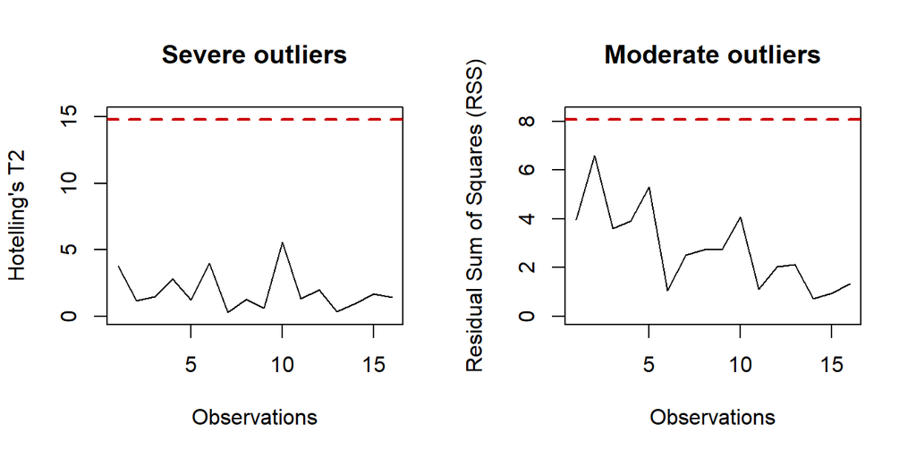

No oil falls outside the 99% limits, so there are no moderate or severe outliers.

### 2.2.2 Validity of the PLS-DA Model

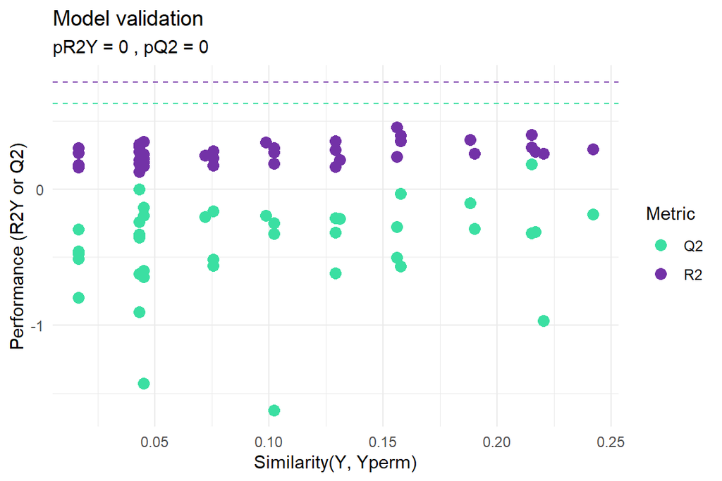

```r
plsPlot(myplsda, type = "overfitting")
```

As we can observe, both the $R^2$ and $Q^2$ values of the PLS-DA model obtained with the unpermuted data are better than those obtained with the permuted data. We can therefore conclude that the obtained model is better than a randomly generated model, and no overfitting appears to be present in the fitted PLS-DA model.

## 2.3 Model Interpretation

We can interpret the model using the following plots:

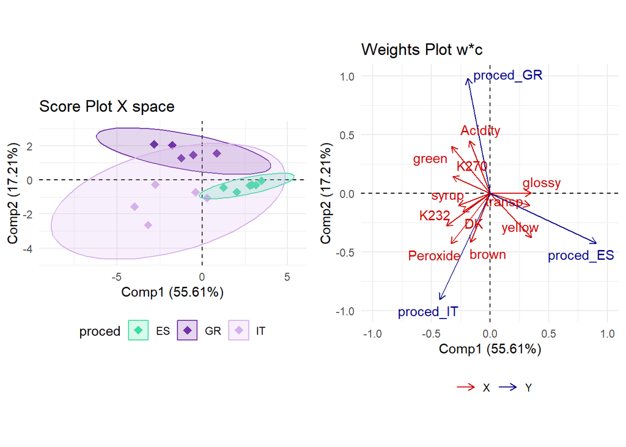

```r
p1 = plsdaPlot(myplsda, type = 'scoresX', comp = 1:2)
p2 = plsdaPlot(myplsda, type = 'weights', comp = 1:2, col = c("red3", "blue4"))
grid.arrange(p1, p2, nrow = 1)
```

## 2.4 Variable Selection in the PLS-DA Model

Like the PLS model, the PLS-DA model provides regression coefficient values and, by default, a confidence interval to test their statistical significance using the *jackknife* procedure. Since we have 3 classes, regression coefficients are obtained for each of them:

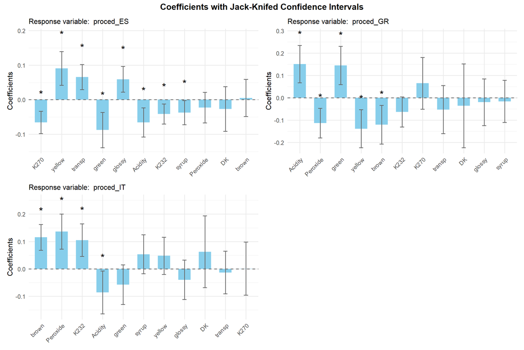

```r
plsPlot(myplsda, type = "coef")
```

Analogously, we can use the **plsVarSel()** function to estimate this significance using other procedures. In this case, we will explore, for example, the VIP:

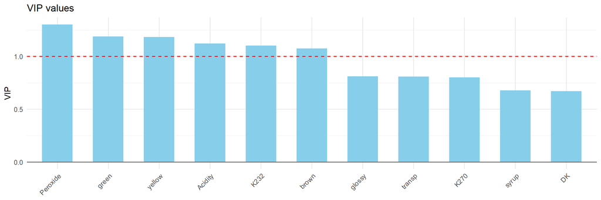

```
##               VIP
## Peroxide 1.302473
## green    1.189113
## yellow   1.183996
## Acidity  1.121433
## K232     1.103126
## brown    1.074000
```

```r
plsVarSel(myplsda, type = 'VIP', threshold = 1)
```

## 2.5 Error Metrics in PLS-DA

We will obtain the error metrics for the oils used to train the model, since no additional data are available.

```r
mypred = predict(myplsda, plot = FALSE)
mypred = factor(mypred$Class$proced)
caret::confusionMatrix(mypred, proced)
```

```
## Confusion Matrix and Statistics
##
##           Reference
## Prediction ES GR IT
##         ES  6  0  0
##         GR  0  5  0
##         IT  0  0  5
##
## Overall Statistics
##
##                Accuracy : 1
##                  95% CI : (0.7941, 1)
##     No Information Rate : 0.375
##     P-Value [Acc > NIR] : 1.529e-07
##
##                   Kappa : 1
##
##  Mcnemar's Test P-Value : NA
##
## Statistics by Class:
##
##                      Class: ES Class: GR Class: IT
## Sensitivity              1.000    1.0000    1.0000
## Specificity              1.000    1.0000    1.0000
## Pos Pred Value           1.000    1.0000    1.0000
## Neg Pred Value           1.000    1.0000    1.0000
## Prevalence               0.375    0.3125    0.3125
## Detection Rate           0.375    0.3125    0.3125
## Detection Prevalence     0.375    0.3125    0.3125
## Balanced Accuracy        1.000    1.0000    1.0000
```